# Assessment 2 - Matt

# Overview

In this assessment we aim to use the MACCDC conn data to perform data analysis and modelling. We first must import the data.

```r
mydata <- read.csv("MAC.csv")
mydata <- data.frame(mydata)
```

```r
mydata
```

| X | ts | uid | id.orig_h | id.orig_p | id.resp_h | id.resp_p | proto | service | duration | orig_bytes | resp_bytes | conn_state | local_orig | missed_bytes | history | orig_pkts | orig_ip_bytes | resp_pkts | resp_ip_bytes |
| --- | --- | --- | --- | --- | --- | --- | --- | --- | --- | --- | --- | --- | --- | --- | --- | --- | --- | --- | --- |
| 5813043 | 1331908160 | CHEoFb1O6PBGt1NEa7 | 192.168.202.110 | 50427 | 192.168.22.102 | 15457 | tcp | - | NA | NA | NA | REJ | NA | 0 | Sr | 1 | 48 | 1 | 40 |
| 11476450 | 1331928816 | Cy6Fv76vPYfgHtCpk | 192.168.202.83 | 46442 | 192.168.206.44 | 42 | tcp | - | NA | NA | NA | REJ | NA | 0 | Sr | 1 | 60 | 1 | 40 |
| 5486523 | 1331907968 | CkpLOHhJomkmlfso3 | 192.168.202.110 | 12662 | 192.168.22.1 | 17800 | tcp | - | NA | NA | NA | S0 | NA | 0 | S | 1 | 48 | 0 | 0 |
| 18708180 | 1332000495 | CMQ0Qy4XI18ermMFhb | 192.168.202.138 | 35203 | 192.168.24.187 | 10629 | tcp | - | NA | NA | NA | S0 | NA | 0 | S | 1 | 44 | 0 | 0 |
| 6090879 | 1331908285 | CiCXbo2GSUPiqsv2Kl | 192.168.202.110 | 63958 | 192.168.22.252 | 56587 | tcp | - | NA | NA | NA | S0 | NA | 0 | S | 1 | 48 | 0 | 0 |
| 1700487 | 1331903789 | C5SBk532nTOCbdcXWf | 192.168.204.45 | 39436 | 192.168.21.101 | 33384 | tcp | - | NA | NA | NA | REJ | NA | 0 | Sr | 1 | 44 | 1 | 40 |
| 4530835 | 1331905416 | Cvtgnu3rcNc9OE5F0g | 192.168.202.83 | 52132 | 192.168.206.44 | 32776 | tcp | - | NA | NA | NA | REJ | NA | 0 | Sr | 1 | 60 | 1 | 40 |
| 11684330 | 1331929548 | CxNCZg20iY4sUIzl8d | 192.168.204.45 | 41741 | 192.168.23.102 | 7476 | tcp | - | NA | NA | NA | S0 | NA | 0 | S | 1 | 60 | 0 | 0 |
| 6971915 | 1331909944 | C6iKiCA4jmAUXr4s8 | 192.168.202.83 | 40224 | 192.168.206.44 | 1688 | tcp | - | NA | NA | NA | REJ | NA | 0 | Sr | 1 | 60 | 1 | 40 |
| 8653157 | 1331920773 | CotShS2qs3FeRJA2wg | 192.168.202.79 | 63022 | 192.168.28.100 | 2010 | tcp | - | NA | NA | NA | S0 | NA | 0 | S | 1 | 44 | 0 | 0 |

[output cut: 990 more lines]

We first want to look for missing data. Service, duration, orig_bytes, resp_bytes and local_orig all seem to have missing data in them so we will see what percentage.

```r
mtab0=data.frame(
    missingduration=is.na(mydata[,"duration"]),
    proto=mydata[,"proto"])
mtab0=table(mtab0)
(apply(mtab0,2,function(x)x/sum(x)))
```

```
               proto
missingduration      icmp       tcp       udp
          FALSE 0.8585338 0.1656118 0.3089144
          TRUE  0.1414662 0.8343882 0.6910856
```

```r
mtab1=data.frame(
    missing_orig_bytes=is.na(mydata[,"orig_bytes"]),
    proto=mydata[,"proto"])
mtab1=table(mtab1)
(apply(mtab1,2,function(x)x/sum(x)))
```

```
                  proto
missing_orig_bytes      icmp       tcp       udp
             FALSE 0.8585338 0.1656118 0.3089144
             TRUE  0.1414662 0.8343882 0.6910856
```

```r
mtab2=data.frame(
    missing_resp_bytes=is.na(mydata[,"resp_bytes"]),
    proto=mydata[,"proto"])
mtab2=table(mtab2)
(apply(mtab2,2,function(x)x/sum(x)))
```

```
                  proto
missing_resp_bytes      icmp       tcp       udp
             FALSE 0.8585338 0.1656118 0.3089144
             TRUE  0.1414662 0.8343882 0.6910856
```

```r
mtab3=data.frame(
    missing_local_orig=is.na(mydata[,"local_orig"]),
    proto=mydata[,"proto"])
mtab3=table(mtab3)
(apply(mtab3,2,function(x)x/sum(x)))
```

```
icmp  tcp  udp
   1    1    1
```

Thus we are missing the local_orig feature for every data point in the data set. We may then consider dropping this entire column as it serves no use to us and we cannot impute the data without prior knowledge of the data set and what it should look like. The duration, orig_bytes and resp_bytes all appear to be missing exactly the same data - on further analysis, we see that whenever one is missing, all three are missing.

Some initial data cleansing will come from removing the X column and the ts column. The X column is produced by the sampling and since we have a random sample of the data, the ts provides no real information on the data.

```r
unique_uid <- mydata[!duplicated(mydata[,c('uid')]),]
unique_uid
```

|  | X | ts | uid | id.orig_h | id.orig_p | id.resp_h | id.resp_p | proto | service | duration | orig_bytes | resp_bytes | conn_state | local_orig | missed_bytes | history | orig_pkts | orig_ip_bytes | resp_pkts | resp_ip_bytes |
| --- | --- | --- | --- | --- | --- | --- | --- | --- | --- | --- | --- | --- | --- | --- | --- | --- | --- | --- | --- | --- |
| 1 | 5813043 | 1331908160 | CHEoFb1O6PBGt1NEa7 | 192.168.202.110 | 50427 | 192.168.22.102 | 15457 | tcp | - | NA | NA | NA | REJ | NA | 0 | Sr | 1 | 48 | 1 | 40 |
| 2 | 11476450 | 1331928816 | Cy6Fv76vPYfgHtCpk | 192.168.202.83 | 46442 | 192.168.206.44 | 42 | tcp | - | NA | NA | NA | REJ | NA | 0 | Sr | 1 | 60 | 1 | 40 |
| 3 | 5486523 | 1331907968 | CkpLOHhJomkmlfso3 | 192.168.202.110 | 12662 | 192.168.22.1 | 17800 | tcp | - | NA | NA | NA | S0 | NA | 0 | S | 1 | 48 | 0 | 0 |
| 4 | 18708180 | 1332000495 | CMQ0Qy4XI18ermMFhb | 192.168.202.138 | 35203 | 192.168.24.187 | 10629 | tcp | - | NA | NA | NA | S0 | NA | 0 | S | 1 | 44 | 0 | 0 |
| 5 | 6090879 | 1331908285 | CiCXbo2GSUPiqsv2Kl | 192.168.202.110 | 63958 | 192.168.22.252 | 56587 | tcp | - | NA | NA | NA | S0 | NA | 0 | S | 1 | 48 | 0 | 0 |
| 6 | 1700487 | 1331903789 | C5SBk532nTOCbdcXWf | 192.168.204.45 | 39436 | 192.168.21.101 | 33384 | tcp | - | NA | NA | NA | REJ | NA | 0 | Sr | 1 | 44 | 1 | 40 |
| 7 | 4530835 | 1331905416 | Cvtgnu3rcNc9OE5F0g | 192.168.202.83 | 52132 | 192.168.206.44 | 32776 | tcp | - | NA | NA | NA | REJ | NA | 0 | Sr | 1 | 60 | 1 | 40 |
| 8 | 11684330 | 1331929548 | CxNCZg20iY4sUIzl8d | 192.168.204.45 | 41741 | 192.168.23.102 | 7476 | tcp | - | NA | NA | NA | S0 | NA | 0 | S | 1 | 60 | 0 | 0 |
| 9 | 6971915 | 1331909944 | C6iKiCA4jmAUXr4s8 | 192.168.202.83 | 40224 | 192.168.206.44 | 1688 | tcp | - | NA | NA | NA | REJ | NA | 0 | Sr | 1 | 60 | 1 | 40 |
| 10 | 8653157 | 1331920773 | CotShS2qs3FeRJA2wg | 192.168.202.79 | 63022 | 192.168.28.100 | 2010 | tcp | - | NA | NA | NA | S0 | NA | 0 | S | 1 | 44 | 0 | 0 |

[output cut: 990 more lines]

Thus all our uid’s are unique and therefore wont provide us with any extra information either since they will be uncorrelated with the rest of the data. This is the only column with this trait, and all other columns have values which occur more than once so we can drop the uid column too.

```r
drop_columns <- c("X","ts","local_orig","uid")
mydata <- mydata[, !names(mydata) %in% drop_columns]
```

```r
head(mydata)
```

|  | id.orig_h | id.orig_p | id.resp_h | id.resp_p | proto | service | duration | orig_bytes | resp_bytes | conn_state | missed_bytes | history | orig_pkts | orig_ip_bytes | resp_pkts | resp_ip_bytes |
| --- | --- | --- | --- | --- | --- | --- | --- | --- | --- | --- | --- | --- | --- | --- | --- | --- |
| 1 | 192.168.202.110 | 50427 | 192.168.22.102 | 15457 | tcp | - | NA | NA | NA | REJ | 0 | Sr | 1 | 48 | 1 | 40 |
| 2 | 192.168.202.83 | 46442 | 192.168.206.44 | 42 | tcp | - | NA | NA | NA | REJ | 0 | Sr | 1 | 60 | 1 | 40 |
| 3 | 192.168.202.110 | 12662 | 192.168.22.1 | 17800 | tcp | - | NA | NA | NA | S0 | 0 | S | 1 | 48 | 0 | 0 |
| 4 | 192.168.202.138 | 35203 | 192.168.24.187 | 10629 | tcp | - | NA | NA | NA | S0 | 0 | S | 1 | 44 | 0 | 0 |
| 5 | 192.168.202.110 | 63958 | 192.168.22.252 | 56587 | tcp | - | NA | NA | NA | S0 | 0 | S | 1 | 48 | 0 | 0 |
| 6 | 192.168.204.45 | 39436 | 192.168.21.101 | 33384 | tcp | - | NA | NA | NA | REJ | 0 | Sr | 1 | 44 | 1 | 40 |

So we have removed the columns that didn’t provide us with any extra information. We will now extract the data we will use for DBSCAN to create clusters. The following code is pulled from Alex’s workbook and allows us to pull out 7 of the features to use for DBSCAN and ensures all elements are numeric.

```r
miss.me <- vector(length = nrow(mydata))
miss.me <- rep(0, times = nrow(mydata))
for(i in 1:nrow(mydata)) {
    if(is.na(mydata$duration[i])) { miss.me[i] <- 1 }
    }
str(mydata)
```

```
'data.frame':   226943 obs. of  16 variables:
 $ id.orig_h    : chr  "192.168.202.110" "192.168.202.83" "192.168.202.110" "192.168.202.138" ...
 $ id.orig_p    : int  50427 46442 12662 35203 63958 39436 52132 41741 40224 63022 ...
 $ id.resp_h    : chr  "192.168.22.102" "192.168.206.44" "192.168.22.1" "192.168.24.187" ...
 $ id.resp_p    : int  15457 42 17800 10629 56587 33384 32776 7476 1688 2010 ...
 $ proto        : chr  "tcp" "tcp" "tcp" "tcp" ...
 $ service      : chr  "-" "-" "-" "-" ...
 $ duration     : num  NA NA NA NA NA NA NA NA NA NA ...
 $ orig_bytes   : int  NA NA NA NA NA NA NA NA NA NA ...
 $ resp_bytes   : int  NA NA NA NA NA NA NA NA NA NA ...
 $ conn_state   : chr  "REJ" "REJ" "S0" "S0" ...
 $ missed_bytes : int  0 0 0 0 0 0 0 0 0 0 ...
 $ history      : chr  "Sr" "Sr" "S" "S" ...
 $ orig_pkts    : int  1 1 1 1 1 1 1 1 1 1 ...
 $ orig_ip_bytes: int  48 60 48 44 48 44 60 60 60 44 ...
 $ resp_pkts    : int  1 1 0 0 0 1 1 0 1 0 ...
 $ resp_ip_bytes: int  40 40 0 0 0 40 40 0 40 0 ...
```

```r
mydata.good <- as.data.frame(cbind(id.orig_p = mydata$id.orig_p, id.resp_p = mydata$id.resp_p,
orig_pkts = mydata$orig_pkts, orig_ip_bytes = mydata$orig_ip_bytes,
resp_pkts = mydata$resp_pkts, resp_ip_bytes = mydata$resp_ip_bytes))
mydata.good<- cbind(mydata.good, miss.me)
head(mydata.good)
```

|  | id.orig_p | id.resp_p | orig_pkts | orig_ip_bytes | resp_pkts | resp_ip_bytes | miss.me |
| --- | --- | --- | --- | --- | --- | --- | --- |
| 1 | 50427 | 15457 | 1 | 48 | 1 | 40 | 1 |
| 2 | 46442 | 42 | 1 | 60 | 1 | 40 | 1 |
| 3 | 12662 | 17800 | 1 | 48 | 0 | 0 | 1 |
| 4 | 35203 | 10629 | 1 | 44 | 0 | 0 | 1 |
| 5 | 63958 | 56587 | 1 | 48 | 0 | 0 | 1 |
| 6 | 39436 | 33384 | 1 | 44 | 1 | 40 | 1 |

```r
str(mydata.good) # Should be only ints and nums
```

```
'data.frame':   226943 obs. of  7 variables:
 $ id.orig_p    : int  50427 46442 12662 35203 63958 39436 52132 41741 40224 63022 ...
 $ id.resp_p    : int  15457 42 17800 10629 56587 33384 32776 7476 1688 2010 ...
 $ orig_pkts    : int  1 1 1 1 1 1 1 1 1 1 ...
 $ orig_ip_bytes: int  48 60 48 44 48 44 60 60 60 44 ...
 $ resp_pkts    : int  1 1 0 0 0 1 1 0 1 0 ...
 $ resp_ip_bytes: int  40 40 0 0 0 40 40 0 40 0 ...
 $ miss.me      : num  1 1 1 1 1 1 1 1 1 1 ...
```

```r
for(i in 1:ncol(mydata.good)) { mydata.good[,i] <- as.numeric(mydata.good[,i]) }
str(mydata.good)        ## All should be nums now
```

```
'data.frame':   226943 obs. of  7 variables:
 $ id.orig_p    : num  50427 46442 12662 35203 63958 ...
 $ id.resp_p    : num  15457 42 17800 10629 56587 ...
 $ orig_pkts    : num  1 1 1 1 1 1 1 1 1 1 ...
 $ orig_ip_bytes: num  48 60 48 44 48 44 60 60 60 44 ...
 $ resp_pkts    : num  1 1 0 0 0 1 1 0 1 0 ...
 $ resp_ip_bytes: num  40 40 0 0 0 40 40 0 40 0 ...
 $ miss.me      : num  1 1 1 1 1 1 1 1 1 1 ...
```

```r
# sum(mydata.good$miss.me)/nrow(mydata.good) ## 82.7% missing
```

I dont want to drop any data that may be important so I’ll also use the protocol, connection state and history features in my analysis.

```r
proto <- as.factor(c(mydata$proto))
proto <- unclass(proto)

conn_state <- as.factor(c(mydata$conn_state))
conn_state <- unclass(conn_state)

history <- as.factor(c(mydata$history))
history <- unclass(history)

mydata.good$proto <- proto
mydata.good$conn_state <- conn_state
mydata.good$history <- history

mydata.good
```

| id.orig_p | id.resp_p | orig_pkts | orig_ip_bytes | resp_pkts | resp_ip_bytes | miss.me | proto | conn_state | history |
| --- | --- | --- | --- | --- | --- | --- | --- | --- | --- |
| 50427 | 15457 | 1 | 48 | 1 | 40 | 1 | 2 | 2 | 145 |
| 46442 | 42 | 1 | 60 | 1 | 40 | 1 | 2 | 2 | 145 |
| 12662 | 17800 | 1 | 48 | 0 | 0 | 1 | 2 | 7 | 28 |
| 35203 | 10629 | 1 | 44 | 0 | 0 | 1 | 2 | 7 | 28 |
| 63958 | 56587 | 1 | 48 | 0 | 0 | 1 | 2 | 7 | 28 |
| 39436 | 33384 | 1 | 44 | 1 | 40 | 1 | 2 | 2 | 145 |
| 52132 | 32776 | 1 | 60 | 1 | 40 | 1 | 2 | 2 | 145 |
| 41741 | 7476 | 1 | 60 | 0 | 0 | 1 | 2 | 7 | 28 |
| 40224 | 1688 | 1 | 60 | 1 | 40 | 1 | 2 | 2 | 145 |
| 63022 | 2010 | 1 | 44 | 0 | 0 | 1 | 2 | 7 | 28 |

[output cut: 990 more lines]

```r
    ## We'll do 10-fold CV and then apply DBSCAN, training on 90%
dg <- mydata.good
ran <- sample(1:nrow(dg), 0.9 * nrow(dg))
nor <-function(x) { (x -min(x))/(max(x)-min(x))   }
dg_norm <- as.data.frame(lapply(dg, nor))
    # head(dg_norm)

dg_train <- dg_norm[ran,]   ## extract training set
dg_test <- dg_norm[-ran,]       ## extract testing set
dg_target_cat <- dg[ran, ncol(dg)]
dg_test_cat <- dg[-ran, ncol(dg)]
```

Now we can look at running DBSCAN on our data. We first need to perform PCA to figure out how many principle components to use in DBSCAN.

```r
library("dbscan")
```

```r
dg_train.svd <- svd(dg_train)
```

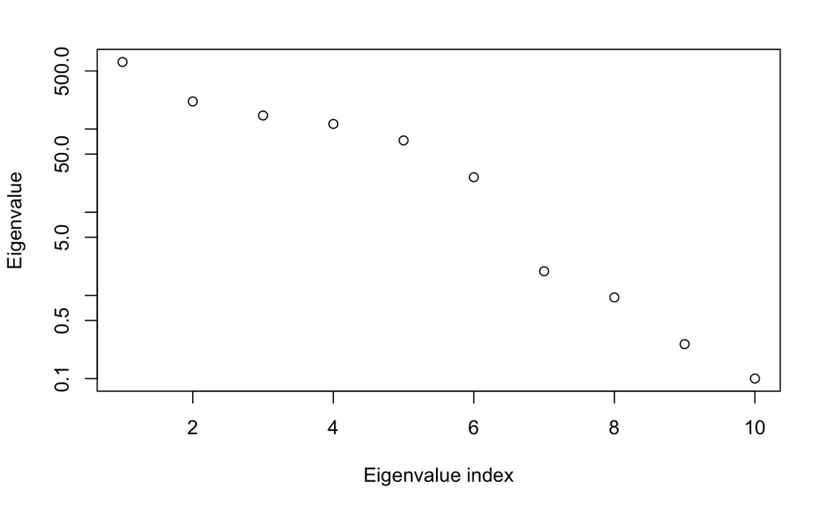

```r
plot(dg_train.svd$d,xlab="Eigenvalue index",ylab="Eigenvalue",log="y")
```

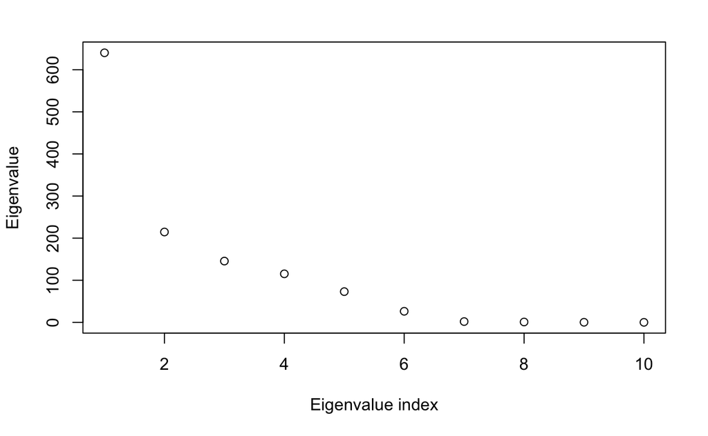

```r
plot(dg_train.svd$d,xlab="Eigenvalue index",ylab="Eigenvalue")
```

Plotting with a log y-axis and a normal y-axis give strikingly different results. The first eigenvector explains most of the variance and the 5 after that seeming explain almost the same amount of variance between them as the first one. I don’t think using just the first eigenvalue would provide that much insight and therefore will use 6 of them (this is still reducing dimensionality by almost half).

```r
npcs = 6
```

We now plot the PCA to visualise the clusters formed here. We’re not plotting according to any categorical data i.e. normal vs non-normal so we may not get that much information from this.

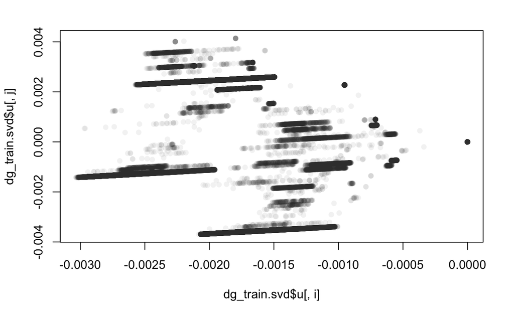

```r
i=1;j=2
plot(dg_train.svd$u[,i],
     dg_train.svd$u[,j],type="p",
     col="#33333311",pch=16,cex=1)
```

Eps specifies how close the points should be to each other to form a cluster. If the distance is less than eps, they are considered neighbours. We find this number by finding the ‘knee’ in the plot below. I have chosen to use 7 neighbours here.

```r
test=kNNdist(dg_train.svd$u[,1:npcs], k = 7,all=TRUE)
testmin=apply(test,1,min)
```

```r
plot(sort(testmin[testmin>1e-8]),log="y")
threshholds= c(0.01,0.001,0.0001,0.00001,0.000001)
abline(h=c(0.01,0.001,0.0001,0.00001,0.000001))
```

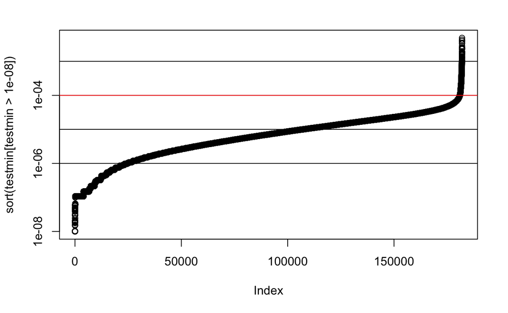

```r
abline(h=0.0001, col="red")
```

Now we finally perform DBSCAN.

```r
dbscanres = dbscan(dg_train.svd$u[,1:6],eps = 0.0001,minPts = 20)
```

```r
dbscanres
```

```
DBSCAN clustering for 204248 objects.
Parameters: eps = 1e-04, minPts = 20
The clustering contains 201 cluster(s) and 25893 noise points.

    0     1     2     3     4     5     6     7     8     9    10    11    12    13    14
25893 71613 75222   792 16053   126   669  1362    43    39    65   452   126   168   326
   15    16    17    18    19    20    21    22    23    24    25    26    27    28    29
  157    95   280    98   109    33    44   230   125   158   109    97    33   381   174
   30    31    32    33    34    35    36    37    38    39    40    41    42    43    44
  326    63    41    64    50   251   161    37    41    45    43   220    48   188    85
   45    46    47    48    49    50    51    52    53    54    55    56    57    58    59
  412    97    62    29   113    37   204   187   110   225    94    47   237   112    38
   60    61    62    63    64    65    66    67    68    69    70    71    72    73    74
   44    62    64   127    27    22    79    25    80    43    40    46    34    41   126
   75    76    77    78    79    80    81    82    83    84    85    86    87    88    89
```

[output cut: 19 more lines]

```r
jpeg("Assessment2 DBSCAN Clustering.jpg")

for (k in 1:5){
    a = seq(k,5)
    for (l in a){
        if(k==l){next}
        plot(dg_train.svd$u[,k],
            dg_train.svd$u[,l],xlab="",
            ylab="",
            col=c("#66666666",rainbow(41))[dbscanres$cluster+1],pch=19,cex=0.5)
    par(new=TRUE)
    }
}
dev.off()
```

```r
jpeg("Assessment2 DBSCAN Clustering Eigenvector split.jpg")
op <- par(mfrow=c(3,4))
for (k in 1:5){
    a = seq(k,5)
    for (l in a){
        if(k==l){next}
        plot(dg_train.svd$u[,k],
            dg_train.svd$u[,l],xlab=k,
            ylab=l,
            col=c("#66666666",rainbow(41))[dbscanres$cluster+1],pch=19,cex=0.5)
    }
}
par(op)
dev.off()
```

References:

1. [Data from SecRepo](https://www.secrepo.com)
2. [Converting categorical variables](https://stackoverflow.com/questions/47922184/convert-categorical-variables-to-numeric-in-r/47923178)
3. [Adding columns to data frames](https://discuss.analyticsvidhya.com/t/how-to-add-a-column-to-a-data-frame-in-r/3278)
4. [Finding Unique Values](https://stackoverflow.com/questions/41906878/r-number-of-unique-values-in-a-column-of-data-frame)
5. [DBSCAN on flowers](https://www.geeksforgeeks.org/dbscan-clustering-in-r-programming/)
6. [Saving Plots](http://www.sthda.com/english/wiki/creating-and-saving-graphs-r-base-graphs)
7. [DBSCAN Parameter Estimation](https://en.wikipedia.org/wiki/DBSCAN#Parameter_estimation)
8. [Finding the knee in kNNDist](https://www.rdocumentation.org/packages/dbscan/versions/1.1-5/topics/kNNdist)